# Actividad Integradora 2

# 4. Analiza las predicciones para los datos de entrenamiento

## Elabora la matriz de confusión

```r
train_predictions = predict(best_model, newdata = train_data, type = "response")
train_data$Predicted = ifelse(train_predictions > 0.5, 1, 0) # Clasificamos como '1' (sobrevive) o '0' (no sobrevive) usando un umbral de 0.5

confusion_matrix = table(Predicted = train_data$Predicted, Actual = train_data$Survived)
accuracy = sum(diag(confusion_matrix)) / sum(confusion_matrix)

cat("Matriz de Confusión:\n")
```

```
## Matriz de Confusión:
```

```r
print(confusion_matrix)
```

```
##          Actual
## Predicted   0   1
##         0 409  69
##         1  42 209
```

```r
cat("\nPrecisión:", round(accuracy, 2))
```

```
##
## Precisión: 0.85
```

## Elabora la Curva ROC

```r
library(pROC)
```

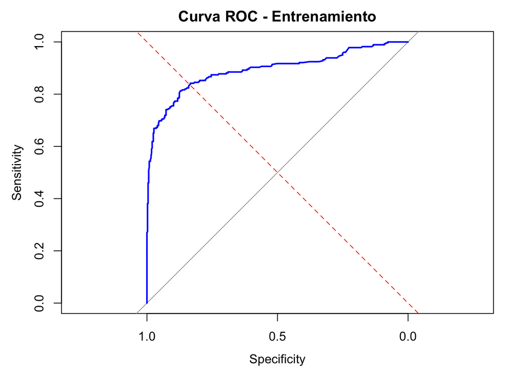

```r
roc_curve = roc(train_data$Survived, train_predictions)
plot(roc_curve, col = "blue", main = "Curva ROC - Entrenamiento")
abline(a = 0, b = 1, lty = 2, col = "red")
```

```r
cat("\nÁrea bajo la curva (AUC):", round(auc(roc_curve), 3), "\n")
```

```
##
## Área bajo la curva (AUC): 0.893
```

## Elabora el gráfico de violín

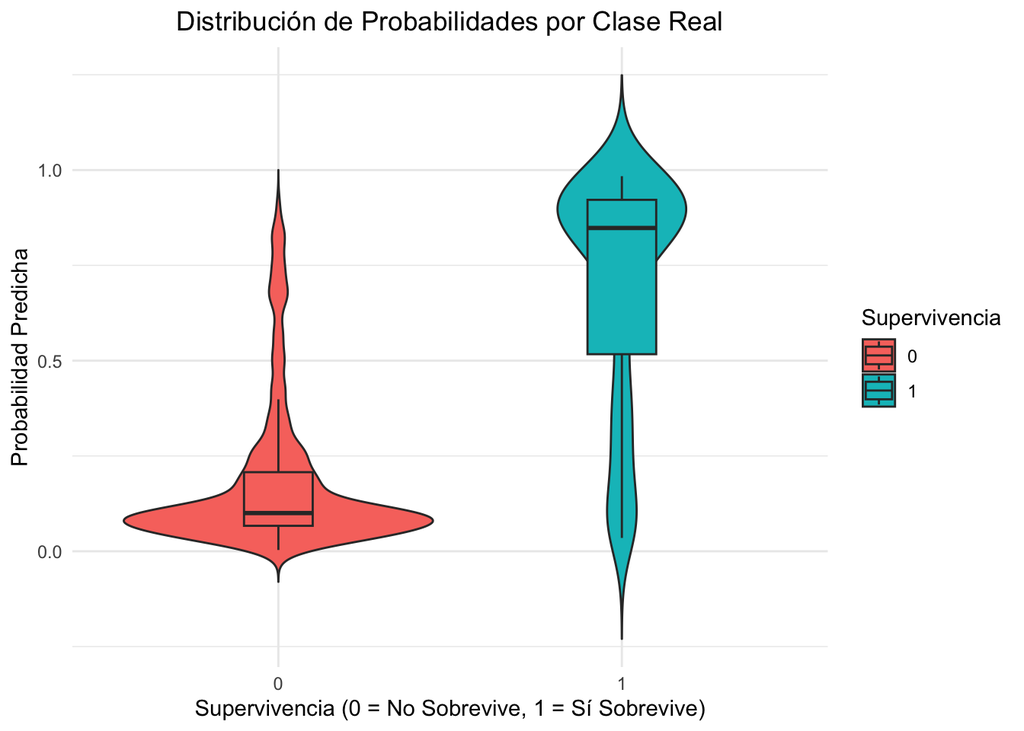

```r
library(ggplot2)

ggplot(train_data, aes(x = as.factor(Survived), y = train_predictions, fill = as.factor(Survived))) +
  geom_violin(trim = FALSE) +
  geom_boxplot(width = 0.2, position = position_dodge(0.9), outlier.shape = NA) +
  labs(title = "Distribución de Probabilidades por Clase Real",
       x = "Supervivencia (0 = No Sobrevive, 1 = Sí Sobrevive)",
       y = "Probabilidad Predicha",
       fill = "Supervivencia") +
  theme_minimal() +
  theme(plot.title = element_text(hjust = 0.5))
```

# 5. Validación del modelo con la base de datos de validación

## Elije un umbral de clasificación óptimo

```r
test_data_clean = na.omit(test_data)
validation_predictions_clean = predict(best_model, newdata = test_data_clean, type = "response")
validation_roc = roc(test_data_clean$Survived, validation_predictions_clean)
optimal_coords = coords(validation_roc, "all", ret = c("threshold", "sensitivity", "specificity"), transpose = FALSE)
```

```r
optimal_threshold = coords(validation_roc, "best", ret = "threshold", transpose = FALSE)
# cat("Umbral ajustado:", adjusted_threshold, "\n")
adjusted_threshold = 0.33

test_data_clean$Predicted = ifelse(validation_predictions_clean > adjusted_threshold, 1, 0)
confusion_matrix_validation = table(Predicted = test_data_clean$Predicted, Actual = test_data_clean$Survived)
accuracy_validation = sum(diag(confusion_matrix_validation)) / sum(confusion_matrix_validation)
```

## Elabora la matriz de confusión con el umbral de clasificación óptimo

```r
cat("\nMatriz de Confusión (Validación):\n")
```

```
##
## Matriz de Confusión (Validación):
```

```r
print(confusion_matrix_validation)
```

```
##          Actual
## Predicted   0   1
##         0 141  20
##         1  36 117
```

```r
cat("\nPrecisión (Validación):", round(accuracy_validation, 2))
```

```
##
## Precisión (Validación): 0.82
```

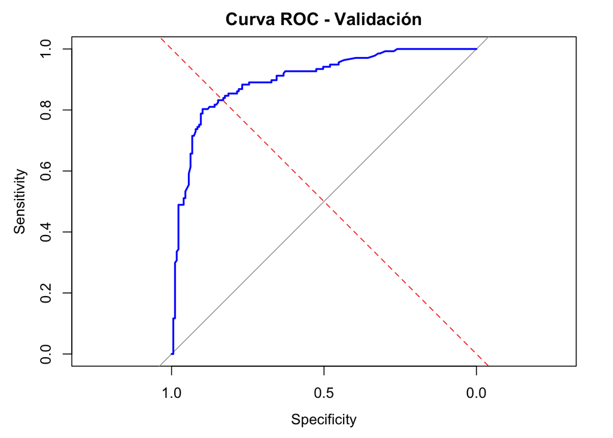

```r
plot(validation_roc, col = "blue", main = "Curva ROC - Validación")
abline(a = 0, b = 1, lty = 2, col = "red")
```

```r
cat("\nÁrea bajo la curva (AUC):", round(auc(validation_roc), 3), "\n")
```

```
##
## Área bajo la curva (AUC): 0.9
```

# 6. Elabora el testeo con la base de datos de prueba.

```r
test_data_final = read.csv("Titanic_test.csv")

cat("Estructura inicial de los datos de prueba:\n")
```

```
## Estructura inicial de los datos de prueba:
```

```r
str(test_data_final)
```

```
## 'data.frame':    418 obs. of  11 variables:
##  $ PassengerId: int  892 893 894 895 896 897 898 899 900 901 ...
##  $ Pclass     : int  3 3 2 3 3 3 3 2 3 3 ...
##  $ Name       : chr  "Kelly, Mr. James" "Wilkes, Mrs. James (Ellen Needs)" "Myles, Mr. Thomas Francis" "Wirz, Mr. Albert" ...
##  $ Sex        : chr  "male" "female" "male" "male" ...
##  $ Age        : num  34.5 47 62 27 22 14 30 26 18 21 ...
##  $ SibSp      : int  0 1 0 0 1 0 0 1 0 2 ...
##  $ Parch      : int  0 0 0 0 1 0 0 1 0 0 ...
##  $ Ticket     : chr  "330911" "363272" "240276" "315154" ...
##  $ Fare       : num  7.83 7 9.69 8.66 12.29 ...
##  $ Cabin      : chr  "" "" "" "" ...
##  $ Embarked   : chr  "Q" "S" "Q" "S" ...
```

```r
test_data_final$Pclass = as.factor(test_data_final$Pclass)
test_data_final$Sex = as.factor(test_data_final$Sex)
test_data_final$Embarked = as.factor(test_data_final$Embarked)
test_data_final_clean = na.omit(test_data_final)
```

```r
final_predictions = predict(best_model, newdata = test_data_final_clean, type = "response")
cat("Número de predicciones generadas:", length(final_predictions), "\n")
```

```
## Número de predicciones generadas: 331
```

```r
adjusted_threshold = 0.3
test_data_final_clean$Predicted = ifelse(final_predictions > adjusted_threshold, 1, 0)

#output = data.frame(PassengerId = test_data_final_clean$PassengerId, Predicted = test_data_final_clean$Predicted)
#write.csv(output, "Titanic_test_predictions.csv", row.names = FALSE)
```

# 7. Concluye en el contexto del problema:

## Define las principales características que influyen en el modelo seleccionado e interpretalas: ¿qué características tuvieron las personas que sobrevivieron?

Después de todo este show, lo que hace el análisis de nuestro modelo logístico nos ayuda a identificar las principales características que influyen en la probabilidad de supervivencia de una persona en el Titanic.

Variables:

*(Pclass):* La clase socioeconómica tuvo un impacto significativo en la supervivencia, Los pasajeros de primera clase tuvieron una mayor probabilidad de sobrevivir vs los de tercera clase que tuvieron la probabilidad más baja.

*(Sex):* Ser mujer aumenta significativamente la probabilidad de supervivencia ya que los hombres tienen una probabilidad mucho más baja de sobrevivir.

*Edad (Age):* La edad también tiene efecto en la probabilidad de supervivencia.

### Entonces podemos describir a las personas que sobrevivieron, de acuerdo con el modelo:

Clase Alta, Mujeres y Niños.

## Interpreta los coeficientes del modelo

```r
summary(best_model)
```

```
##
## Call:
## glm(formula = Survived ~ Pclass + Sex + Age + SibSp, family = binomial,
##     data = train_data)
##
## Deviance Residuals:
##     Min       1Q   Median       3Q      Max
## -2.2283  -0.4944  -0.3428   0.4607   2.5900
##
## Coefficients:
##              Estimate Std. Error z value Pr(>|z|)
## (Intercept)  4.801075   0.513306   9.353  < 2e-16 ***
## Pclass2     -1.360143   0.313370  -4.340 1.42e-05 ***
## Pclass3     -2.319298   0.308325  -7.522 5.38e-14 ***
## Sexmale     -3.788652   0.256399 -14.776  < 2e-16 ***
## Age         -0.043149   0.009025  -4.781 1.74e-06 ***
## SibSp       -0.470568   0.141493  -3.326 0.000882 ***
## ---
## Signif. codes:  0 '***' 0.001 '**' 0.01 '*' 0.05 '.' 0.1 ' ' 1
##
## (Dispersion parameter for binomial family taken to be 1)
##
##     Null deviance: 969.16  on 728  degrees of freedom
## Residual deviance: 540.30  on 723  degrees of freedom
## AIC: 552.3
##
## Number of Fisher Scoring iterations: 5
```

*Intercepto:* Su valor positivo indica que la probabilidad de supervivencia en esta categoría es alta. *Pclass2 y Pclass3:*: Coeficiente negativo significa que estar en segunda clase reduce la probabilidad de supervivencia en comparación con la primera clase. Lo mismo para la tercera clase. *Sexmale:* Coeficiente negativo indica que los hombres tienen una probabilidad mucho más baja de sobrevivir en comparación con las mujeres. *Age:* Coeficiente negativo indica que, por cada aumento en un año de edad, la probabilidad de supervivencia disminuye ligeramente.

Se obtiene que: *Positivo o de Mayor probabilidad: Ser mujer, de primera clase y menor edad.*

Que concuerda con lo anterior.

## Define cuál es el mejor umbral de clasificación y por qué

```r
roc_curve = roc(train_data$Survived, predict(best_model, newdata = train_data, type = "response"))
optimal_threshold = coords(roc_curve, "best", ret = "threshold", transpose = FALSE)
print(round(optimal_threshold, 3))
```

```
##   threshold
## 1     0.366
```

```r
optimal_metrics = coords(roc_curve, "best", ret = c("sensitivity", "specificity"), transpose = FALSE)
```

El umbral óptimo identificado es 0.366, nos indica que la si probabilidad predicha por el modelo es mayor o igual a 0.366, clasificamos la observación como 1 (sobrevive), si es menor, se clasifica como 0 (no sobrevive). Lo que maximiza el balance entre sensibilidad (detecta correctamente a los sobrevivientes) y especificidad (detecta correctamente a los no sobrevivientes) en los datos de entrenamiento o validación.